# Importing Libraryes

```python
# Data manipulation
import pandas as pd
import numpy as np

# Data visualization
import matplotlib.pyplot as plt
import seaborn as sns

# Display settings (optional but good practice)
pd.set_option('display.max_columns', None)
```

# Uploading CSV File path connect to file

```python
df = pd.read_csv(r"D:\Desktop\BigMarketSales\Train.csv")
```

```python
df.head()
```

|  | Item_Identifier | Item_Weight | Item_Fat_Content | Item_Visibility | Item_Type | Item_MRP | Outlet_Identifier | Outlet_Establishment_Year | Outlet_Size | Outlet_Location_Type | Outlet_Type | Item_Outlet_Sales |
| --- | --- | --- | --- | --- | --- | --- | --- | --- | --- | --- | --- | --- |
| 0 | FDA15 | 9.30 | Low Fat | 0.016047 | Dairy | 249.8092 | OUT049 | 1999 | Medium | Tier 1 | Supermarket Type1 | 3735.1380 |
| 1 | DRC01 | 5.92 | Regular | 0.019278 | Soft Drinks | 48.2692 | OUT018 | 2009 | Medium | Tier 3 | Supermarket Type2 | 443.4228 |
| 2 | FDN15 | 17.50 | Low Fat | 0.016760 | Meat | 141.6180 | OUT049 | 1999 | Medium | Tier 1 | Supermarket Type1 | 2097.2700 |
| 3 | FDX07 | 19.20 | Regular | 0.000000 | Fruits and Vegetables | 182.0950 | OUT010 | 1998 | Medium | Tier 3 | Grocery Store | 732.3800 |
| 4 | NCD19 | 8.93 | Low Fat | 0.000000 | Household | 53.8614 | OUT013 | 1987 | High | Tier 3 | Supermarket Type1 | 994.7052 |

```python
df.shape
```

```
(8523, 12)
```

# File Data Types

```python
df.info()
```

```
<class 'pandas.core.frame.DataFrame'>
RangeIndex: 8523 entries, 0 to 8522
Data columns (total 12 columns):
 #   Column                     Non-Null Count  Dtype
---  ------                     --------------  -----
 0   Item_Identifier            8523 non-null   object
 1   Item_Weight                8523 non-null   float64
 2   Item_Fat_Content           8523 non-null   object
 3   Item_Visibility            8523 non-null   float64
 4   Item_Type                  8523 non-null   object
 5   Item_MRP                   8523 non-null   float64
 6   Outlet_Identifier          8523 non-null   object
 7   Outlet_Establishment_Year  8523 non-null   int64
 8   Outlet_Size                8523 non-null   object
 9   Outlet_Location_Type       8523 non-null   object
 10  Outlet_Type                8523 non-null   object
 11  Item_Outlet_Sales          8523 non-null   float64
dtypes: float64(4), int64(1), object(7)
memory usage: 799.2+ KB
```

```python
df.describe()
```

|  | Item_Weight | Item_Visibility | Item_MRP | Outlet_Establishment_Year | Item_Outlet_Sales |
| --- | --- | --- | --- | --- | --- |
| count | 8523.000000 | 8523.000000 | 8523.000000 | 8523.000000 | 8523.000000 |
| mean | 12.857534 | 0.066132 | 140.992782 | 1997.831867 | 2181.288914 |
| std | 4.226124 | 0.051598 | 62.275067 | 8.371760 | 1706.499616 |
| min | 4.555000 | 0.000000 | 31.290000 | 1985.000000 | 33.290000 |
| 25% | 9.310000 | 0.026989 | 93.826500 | 1987.000000 | 834.247400 |
| 50% | 12.857000 | 0.053931 | 143.012800 | 1999.000000 | 1794.331000 |
| 75% | 16.000000 | 0.094585 | 185.643700 | 2004.000000 | 3101.296400 |
| max | 21.350000 | 0.328391 | 266.888400 | 2009.000000 | 13086.964800 |

```python
categorical_cols = [
    'Item_Type',
    'Outlet_Type',
    'Outlet_Size',
    'Outlet_Location_Type',
    'Item_Fat_Content'
]

for col in categorical_cols:
    df[col] = df[col].astype('category')
```

```python
df.info()
```

```
<class 'pandas.core.frame.DataFrame'>
RangeIndex: 8523 entries, 0 to 8522
Data columns (total 12 columns):
 #   Column                     Non-Null Count  Dtype
---  ------                     --------------  -----
 0   Item_Identifier            8523 non-null   object
 1   Item_Weight                8523 non-null   float64
 2   Item_Fat_Content           8523 non-null   category
 3   Item_Visibility            8523 non-null   float64
 4   Item_Type                  8523 non-null   category
 5   Item_MRP                   8523 non-null   float64
 6   Outlet_Identifier          8523 non-null   object
 7   Outlet_Establishment_Year  8523 non-null   int64
 8   Outlet_Size                8523 non-null   category
 9   Outlet_Location_Type       8523 non-null   category
 10  Outlet_Type                8523 non-null   category
 11  Item_Outlet_Sales          8523 non-null   float64
dtypes: category(5), float64(4), int64(1), object(2)
memory usage: 509.2+ KB
```

```python
df['Item_Identifier'] = df['Item_Identifier'].astype('category')
df['Outlet_Identifier'] = df['Outlet_Identifier'].astype('category')
```

# change date types numerical as float, int and text date should be categorical

```python
df.info()
```

```
<class 'pandas.core.frame.DataFrame'>
RangeIndex: 8523 entries, 0 to 8522
Data columns (total 12 columns):
 #   Column                     Non-Null Count  Dtype
---  ------                     --------------  -----
 0   Item_Identifier            8523 non-null   category
 1   Item_Weight                8523 non-null   float64
 2   Item_Fat_Content           8523 non-null   category
 3   Item_Visibility            8523 non-null   float64
 4   Item_Type                  8523 non-null   category
 5   Item_MRP                   8523 non-null   float64
 6   Outlet_Identifier          8523 non-null   category
 7   Outlet_Establishment_Year  8523 non-null   int64
 8   Outlet_Size                8523 non-null   category
 9   Outlet_Location_Type       8523 non-null   category
 10  Outlet_Type                8523 non-null   category
 11  Item_Outlet_Sales          8523 non-null   float64
dtypes: category(7), float64(4), int64(1)
memory usage: 445.8 KB
```

```python
df['Item_Outlet_Sales'].describe()
```

```
count     8523.000000
mean      2181.288914
std       1706.499616
min         33.290000
25%        834.247400
50%       1794.331000
75%       3101.296400
max      13086.964800
Name: Item_Outlet_Sales, dtype: float64
```

# find Skiweness of outles sales

```python
df['Item_Outlet_Sales'].skew()
```

```
np.float64(1.1775306028542798)
```

```python
df[['Item_MRP','Item_Visibility','Item_Weight']].describe()
```

|  | Item_MRP | Item_Visibility | Item_Weight |
| --- | --- | --- | --- |
| count | 8523.000000 | 8523.000000 | 8523.000000 |
| mean | 140.992782 | 0.066132 | 12.857534 |
| std | 62.275067 | 0.051598 | 4.226124 |
| min | 31.290000 | 0.000000 | 4.555000 |
| 25% | 93.826500 | 0.026989 | 9.310000 |
| 50% | 143.012800 | 0.053931 | 12.857000 |
| 75% | 185.643700 | 0.094585 | 16.000000 |
| max | 266.888400 | 0.328391 | 21.350000 |

# Outlet Type and Size counts

```python
df['Outlet_Type'].value_counts()
df['Outlet_Size'].value_counts()
```

```
Outlet_Size
Medium    5203
Small     2388
High       932
Name: count, dtype: int64
```

# Outlet Type Wise Sales.

```python
df.groupby('Outlet_Type')['Item_Outlet_Sales'].mean()
```

```
Outlet_Type
Grocery Store         339.828500
Supermarket Type1    2316.181148
Supermarket Type2    1995.498739
Supermarket Type3    3694.038558
Name: Item_Outlet_Sales, dtype: float64
```

# finding Outliers in datasets

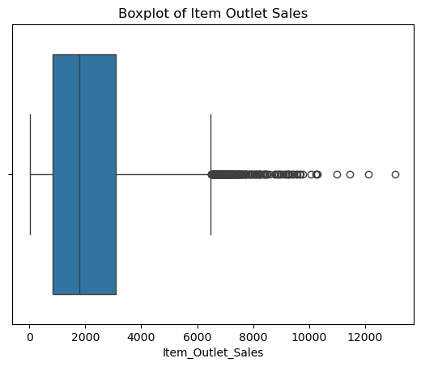

```python
sns.boxplot(x=df['Item_Outlet_Sales'])
plt.title("Boxplot of Item Outlet Sales")
plt.show()
```

A few high-value sales were identified using boxplot and IQR method. These were retained as they represent genuine high-performing items.

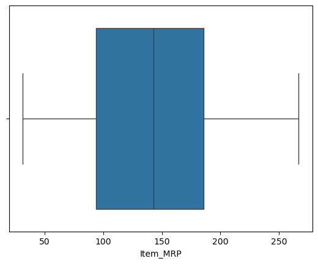

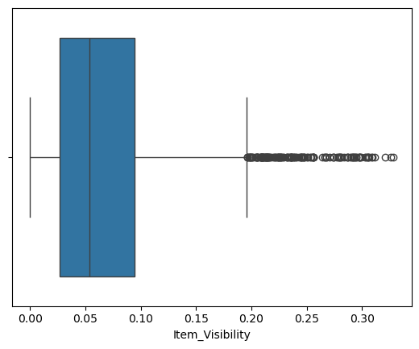

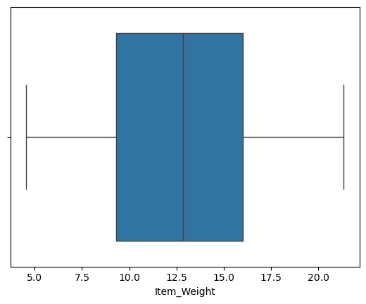

```python
sns.boxplot(x=df['Item_MRP'])
plt.show()

sns.boxplot(x=df['Item_Visibility'])
plt.show()

sns.boxplot(x=df['Item_Weight'])
plt.show()
```

```python
(df['Item_Visibility'] == 0).sum()
```

```
np.int64(526)
```

```python
df.loc[df['Item_Visibility'] == 0, 'Item_Visibility'] = df['Item_Visibility'].median()
```

```python
(df['Item_Visibility'] == 0).sum()
```

```
np.int64(0)
```

```python
df['Item_Visibility'].describe()
```

```
count    8523.000000
mean        0.069460
std         0.048893
min         0.003575
25%         0.033085
50%         0.053931
75%         0.094585
max         0.328391
Name: Item_Visibility, dtype: float64
```

```python
Q1 = df['Item_Visibility'].quantile(0.25)
Q3 = df['Item_Visibility'].quantile(0.75)

IQR = Q3 - Q1

lower_limit = Q1 - 1.5 * IQR
upper_limit = Q3 + 1.5 * IQR

print("Lower limit:", lower_limit)
print("Upper limit:", upper_limit)
```

```
Lower limit: -0.059164579999999994
Upper limit: 0.186835216
```

```python
df_no_outliers = df[
    (df['Item_Visibility'] >= lower_limit) &
    (df['Item_Visibility'] <= upper_limit)
]
```

```python
print("Original shape:", df.shape)
print("After removing outliers:", df_no_outliers.shape)
```

```
Original shape: (8523, 12)
After removing outliers: (8350, 12)
```

Only ~2% data removed

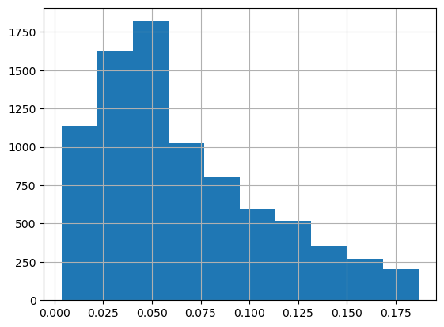

```python
df_no_outliers['Item_Visibility'].hist()
```

Checking Distribution

```python
df_no_outliers[['Item_Visibility','Item_Outlet_Sales']].corr()
```

|  | Item_Visibility | Item_Outlet_Sales |
| --- | --- | --- |
| Item_Visibility | 1.000000 | -0.070416 |
| Item_Outlet_Sales | -0.070416 | 1.000000 |

Correlation with Sales

# Checking Impact on Sales

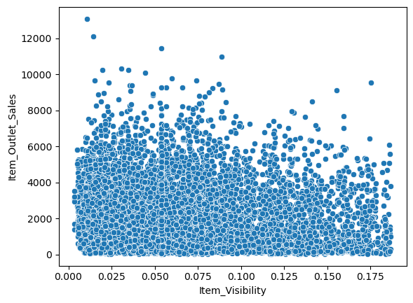

```python
import seaborn as sns
sns.scatterplot(x='Item_Visibility', y='Item_Outlet_Sales', data=df_no_outliers)
```

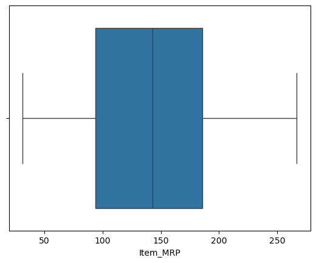

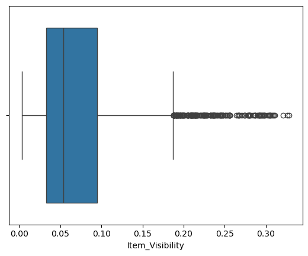

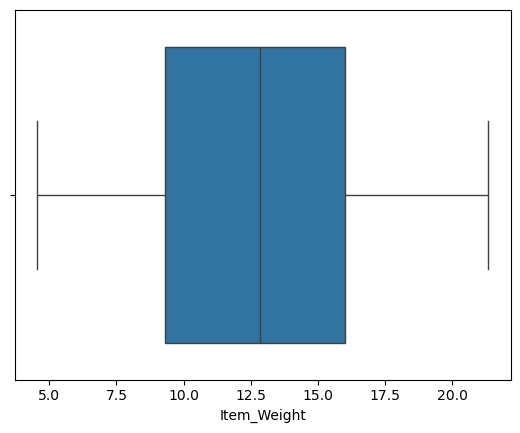

```python
sns.boxplot(x=df['Item_MRP'])
plt.show()

sns.boxplot(x=df['Item_Visibility'])
plt.show()

sns.boxplot(x=df['Item_Weight'])
plt.show()
```

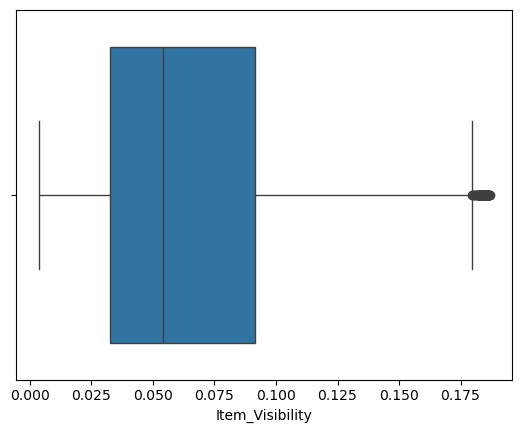

```python
import seaborn as sns
sns.boxplot(x=df_no_outliers['Item_Visibility'])
```

```python
df_no_outliers['Item_Visibility'].max()
```

```
0.186825823
```

# Correlation Heatmap

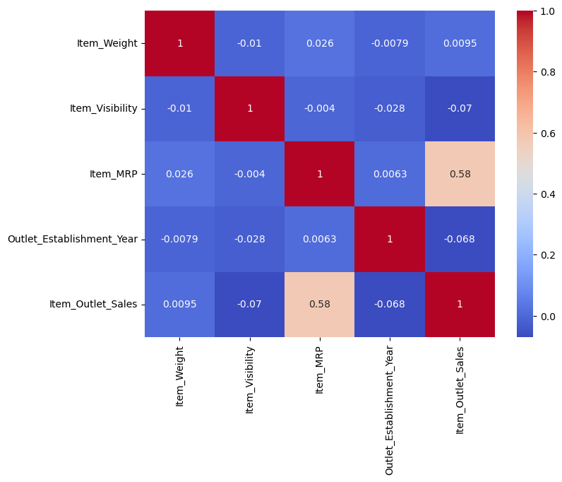

```python
numeric_df = df_no_outliers.select_dtypes(include=['int64','float64'])

plt.figure(figsize=(8,6))
sns.heatmap(numeric_df.corr(), annot=True, cmap='coolwarm')
plt.show()
```

# Correlation Analysis Insight

From the heatmap:

Item_MRP → 0.58 correlation with Sales

Item_Visibility → -0.07 (very weak)

Item_Weight → 0.009 (no relation)

Outlet_Establishment_Year → -0.068 (very weak)

Key Insight: Item_MRP shows a strong positive relationship with Item_Outlet_Sales, indicating that higher-priced products tend to generate higher revenue.

# Sales by Outlet Type

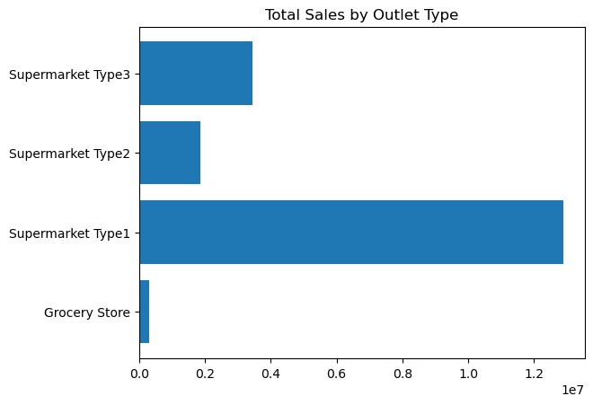

```python
type_sales = df_no_outliers.groupby('Outlet_Type')['Item_Outlet_Sales'].sum().reset_index()

plt.barh(type_sales['Outlet_Type'], type_sales['Item_Outlet_Sales'])
plt.title("Total Sales by Outlet Type")
plt.show()
```

# Sales by Outlet Type – Insights

Supermarket Type 3 generates the highest item-level sales among all outlet types.

Recommendation: Focus marketing and premium product placement in Supermarket Type 3 outlets.

Supermarket Type 1 outlets also contribute significantly to overall revenue. Supermarket Type 2 performs moderately but below Type 1 and Type 3. Grocery Stores generate the lowest sales among all outlet types.

# Sales by Outlet Size

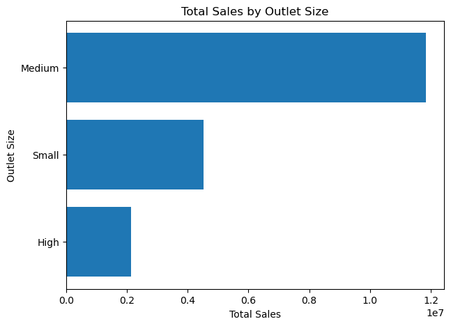

```python
plt.figure(figsize=(7,5))

size_sales = df_no_outliers.groupby('Outlet_Size')['Item_Outlet_Sales'].sum().reset_index()

size_sales = size_sales.sort_values(by='Item_Outlet_Sales', ascending=True)

plt.barh(size_sales['Outlet_Size'], size_sales['Item_Outlet_Sales'])

plt.xlabel("Total Sales")
plt.ylabel("Outlet Size")
plt.title("Total Sales by Outlet Size")
plt.show()
```

# Sales by Outlet Size – Insights

Medium Size Outlets – Highest Revenue 🏆

Strong overall performance

Medium-sized outlets show the strongest sales performance, indicating that optimal store size plays a significant role in revenue generation.

# Sales by Item Type

[output not shown]

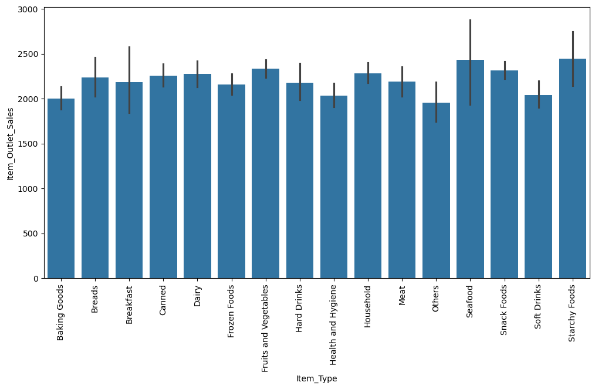

```python
plt.figure(figsize=(12,6))
sns.barplot(x='Item_Type', y='Item_Outlet_Sales', data=df_no_outliers)
plt.xticks(rotation=90)
```

# Sales by Item Type – Insights

Top Performing Categories Highest average sales appear in:

Starchy Foods

Seafood

Fruits and Vegetables

Snack Foods

Household Insight:

Starchy Foods and Seafood categories generate the highest average item-level sales.

Low Performing Categories

Lower average sales seen in:

Baking Goods

Health and Hygiene

Others

Soft Drinks

Insight:

Baking Goods and Health & Hygiene show comparatively lower average sales.

# Important Conclusion

Category-level sales analysis indicates that Starchy Foods and Seafood are top revenue-generating item types, while Baking Goods and Health & Hygiene contribute comparatively lower sales.

# Sales Distribution

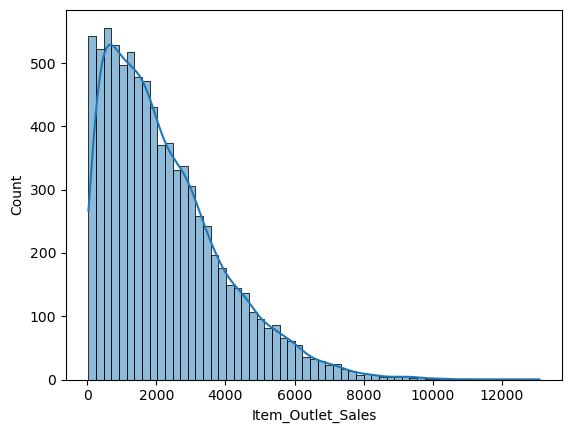

```python
sns.histplot(df_no_outliers['Item_Outlet_Sales'], kde=True)
df_no_outliers['Log_Sales'] = np.log1p(df_no_outliers['Item_Outlet_Sales'])
```

# Sales Distribution – Insights

Right-Skewed Distribution 📈

From the histogram:

Most sales values are concentrated between 0 – 3000

Very few products have extremely high sales (above 8000)

Long tail towards the right

Insight:

Item_Outlet_Sales is positively skewed (right-skewed).

Important Conclusion : The sales distribution is highly right-skewed, indicating that while most products generate moderate revenue, a small number of items contribute disproportionately high sales.

# MRP vs Sales

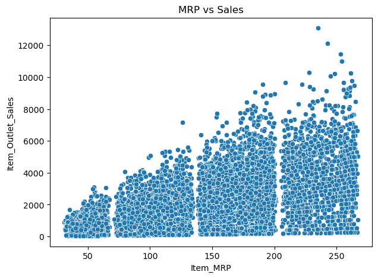

```python
plt.figure(figsize=(7,5))
sns.scatterplot(x='Item_MRP', y='Item_Outlet_Sales', data=df_no_outliers)
plt.title("MRP vs Sales")
plt.show()
```

# Sales by Outlet Location Type(city)

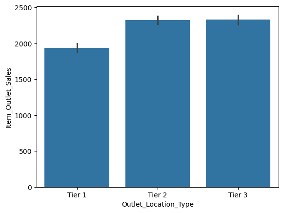

```python
sns.barplot(x='Outlet_Location_Type',
            y='Item_Outlet_Sales',
            data=df_no_outliers)
```

Insight: Which city tier generates more revenue? Almost Tier 2 & Tier 3 city Genrated some amount of Outlet Sales

# Heatmap of Average Sales

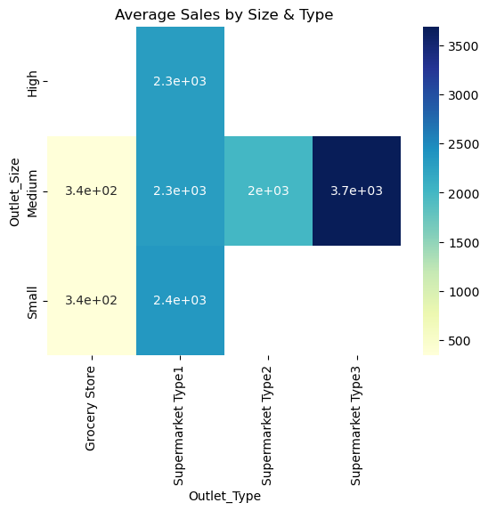

```python
pivot = df_no_outliers.pivot_table(
    values='Item_Outlet_Sales',
    index='Outlet_Size',
    columns='Outlet_Type',
    aggfunc='mean'
)

sns.heatmap(pivot, annot=True, cmap='YlGnBu')
plt.title("Average Sales by Size & Type")
plt.show()
```

# Count of Items per Outlet Type

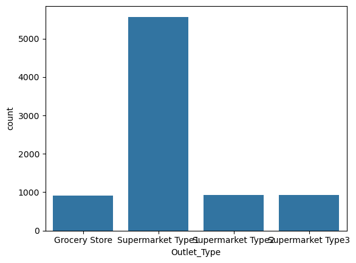

```python
sns.countplot(x='Outlet_Type', data=df_no_outliers)
```

# Sale Trend By Estimated Year

[output not shown]

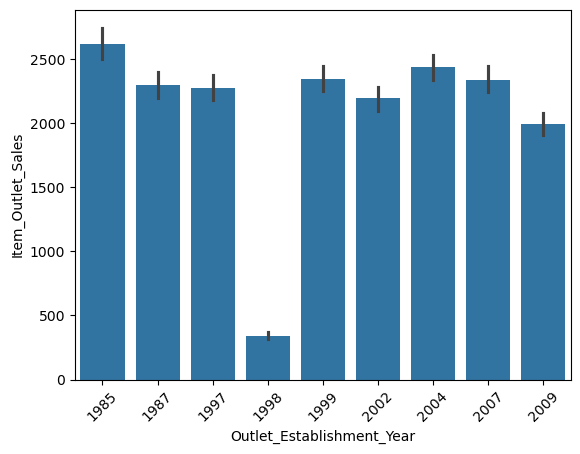

```python
sns.barplot(x='Outlet_Establishment_Year',
            y='Item_Outlet_Sales',
            data=df_no_outliers)
plt.xticks(rotation=45)
```

# Business Insights Summary

Item_MRP strongly impacts sales (0.58 correlation)

Medium-sized outlets perform best

Sales distribution is right-skewed

Visibility has minimal impact on sales

# Business Recommendations

Focus on pricing strategy optimization

Invest more in medium-sized outlets

Expand Supermarket Type 3 format

Promote high-performing categories

```python
df_no_outliers.to_csv("bigmart_cleaned.csv", index=False)
```